# PoC sample for ORR (simulation)

# Find the minimum sample size n

## Algorithm

Grid search:

1. let r=1, increase n from, say 20, to 30; if violate CLINICAL RELAVANCE, stop; Record current n as n1;
2. let r=r+1=2, increase n from n1 to 30 (assume n1<30), repeat the step above until violating CLINICAL RELAVANCE;
3. repeat above steps;
4. if all combination (r,n) (n>n_min) meet both STATISTICAL SIGNIFICANCE and CLINICAL RELAVANCE, then n_min is the minimum sample size.

> Note that we can find such n_min via visualization

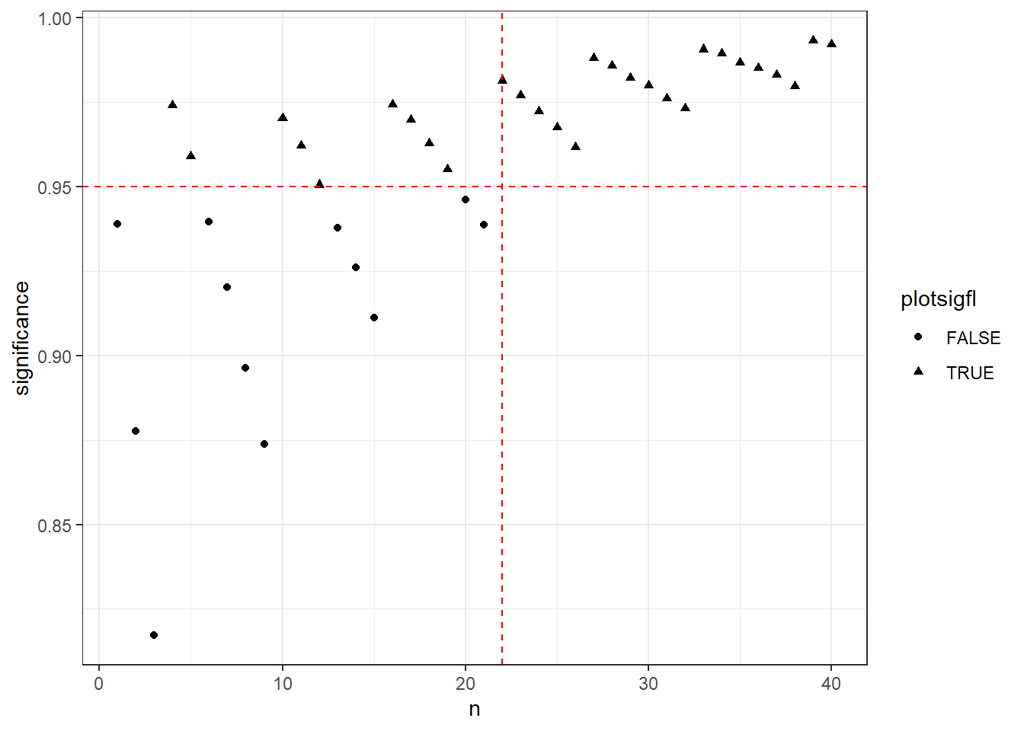

```r
library(dplyr)
library(ggplot2)
library(kableExtra)
# parameters
nv=0.075
dv=0.175
beta_a=0.0811
beta_b=1

df <- data.frame(r=rep(NA,400),
                 n=rep(NA,400),
                 significance=rep(NA,400),
                 postmedian=rep(NA,400),
                 justmedfl=rep(NA,400),
                 bothfl=rep(NA,400))

row <- 1

for (r in 1:10){
  for (n in 1:40){
    if (r>n) {
      next
    }
    rand <- rbeta(100000,beta_a+r,beta_b+n-r)
    sig <- mean(rand>=nv)
    med <- median(rand)
    df[row,1]=r
    df[row,2]=n
    df[row,3]=sig
    df[row,4]=med
    if (sig<0.95 & med>=0.175){df[row,5]=TRUE}
    if (sig>=0.95 & med>=0.175){df[row,6]=TRUE}
    row <- row+1
  }
}

# if there is at least one missing data in df then delete the row.
df_cc <- filter(df,justmedfl==TRUE | bothfl==TRUE)
df_cc['delete'] <- FALSE
# find the minumum sample size by visualization
len_rows <- dim(df_cc)[1]
for (row in (1:len_rows)){
  if ((!(is.na(df_cc[row,'justmedfl'])) & is.na(df_cc[row,'bothfl']))){
    nextn <- df_cc[row,'n']
    maxr <- df_cc[row,'r']
  }
  if (!is.na(df_cc[row,'bothfl']) & df_cc[row,'n']>nextn){
    nextn <- df_cc[row,'n']
    maxr <- df_cc[row,'r']
  }
  if (df_cc[row,'r']>maxr){
    if (df_cc[row,'n']<=nextn){
      df_cc[row,'delete'] <- TRUE
    }
  }
}

# plot
df_cc_plot <- filter(df_cc,delete==FALSE)
df_cc_plot$plotsigfl <- ifelse(is.na(df_cc_plot$bothfl),FALSE,TRUE)
p <- ggplot(data=df_cc_plot, mapping = aes(x=n,y=significance,shape=plotsigfl)) +
  geom_point() +
  geom_hline(yintercept=0.95, linetype="dashed", color = "red") +
  geom_vline(xintercept=22, linetype="dashed", color = "red") +
  theme_bw()
p
```

# Simulation

## Scenario 1 (Dual Criterion)

- $\alpha=0.05$, DV=0.175, n=25;
- True ORR (%) = 7.5, 12.5, 17.5, 22.5, 27.5
- GO: r>=5
- NOGO: r<5

**Why for n=25, the minimum number of responders for a GO is 5?**

We can see that if the #responders < 5, both criteria are missed and NO-GO decision will be made.

```r
alpha <- 0.05
dv <- 0.175
nv <- 0.075
ssn <- 25
beta_a=0.0811
beta_b=1
r_vec <- 1:10
result1 <- matrix(NA,nrow = 3,ncol=10)
result1[1,] <- r_vec

# statistical significance and posterior median
for (r in r_vec){
  rand <- rbeta(10000,beta_a+r,beta_b+ssn-r)
  sig <- mean(rand>=nv)
  med <- median(rand)
  result1[2,r] <- sig
  result1[3,r] <- med
}

df1 <- data.frame(result1)
row.names(df1) <- c("r","statsig","postmedian")
df1 %>%
  kbl(caption = "minimum responders, n=25") %>%
  kable_classic(full_width = F)
```

minimum responders, n=25

|  | X1 | X2 | X3 | X4 | X5 | X6 | X7 | X8 | X9 | X10 |
| --- | --- | --- | --- | --- | --- | --- | --- | --- | --- | --- |
| r | 1.0000000 | 2.0000000 | 3.0000000 | 4.0000000 | 5.0000000 | 6.000000 | 7.0000000 | 8.000000 | 9.0000000 | 10.0000000 |
| statsig | 0.1681000 | 0.4546000 | 0.7325000 | 0.8898000 | 0.9668000 | 0.990800 | 0.9990000 | 0.999700 | 0.9999000 | 1.0000000 |
| postmedian | 0.0313388 | 0.0694278 | 0.1095303 | 0.1479422 | 0.1858373 | 0.225656 | 0.2648358 | 0.305543 | 0.3446998 | 0.3843615 |

**Simulate power: Scen1**

From the above, we see that when n=25:

- r<5: both criteria will be violated, a NO-GO will be made;
- r>=5: both criteria will be achieved, a GO will be made;

*so there is no space for a INCONCLUSIVE decision.*

```r
# function to simulate
sim_binom <- function(orr){
  # parameters
  alpha <- 0.05
  dv <- 0.175
  ssn <- 25

  # responder for GO/NOGO
  r_go <- 5
  r_nogo <- 5

  # simulate responders from binomial distribution
  r <- sum(rbinom(ssn,1,orr))
  goprob <- ifelse(r>=r_go,TRUE,FALSE)
  nogoprob <- ifelse(r<r_nogo,TRUE,FALSE)
  return(c(goprob,nogoprob))
}

# replicate trial to get GO/NO-GO possibilities.
rep_trial=5000

# set seed
set.seed(12)

# orr list
trueORR <- c(7.5, 12.5, 17.5, 22.5, 27.5)*0.01

# sim
resulttotal1 <- data.frame(matrix(0,nrow=5,ncol=4))
colnames(resulttotal1) <- c("true_orr","go","no-go","inconclusive")
i <- 1

for (o in trueORR) {
  # simulate 1000 datasets over true ORR vector
  df11 <- data.frame(t(replicate(rep_trial, sim_binom(orr = o))))
  # Get mean of cols
  df12 <- df11 %>% summarise(
    orr = o,
    successrate = mean(X1),
    failrate = mean(X2),
    incon = 1 - successrate - failrate
  )
  resulttotal1[i,] <- df12[1,]
  i <- i+1
}

resulttotal1 %>%
  kbl(caption = "operating characteristics, n=25") %>%
  kable_classic(full_width = F)
```

operating characteristics, n=25

| true_orr | go | no-go | inconclusive |
| --- | --- | --- | --- |
| 0.075 | 0.0338 | 0.9662 | 0 |
| 0.125 | 0.1976 | 0.8024 | 0 |
| 0.175 | 0.4550 | 0.5450 | 0 |
| 0.225 | 0.6992 | 0.3008 | 0 |
| 0.275 | 0.8580 | 0.1420 | 0 |

## Scenario 2 (Dual Criterion)

- $\alpha=0.05$, DV=0.175, n=36;
- True ORR (%) = 7.5, 12.5, 17.5, 22.5, 27.5
- GO: r>=7
- NOGO: r<=5

**Why for n=36, the minimum number of responders for a GO is 7?**

```r
alpha <- 0.05
dv <- 0.175
nv <- 0.075
ssn <- 36
beta_a=0.0811
beta_b=1
r_vec <- 1:10
result1 <- matrix(NA,nrow = 3,ncol=10)
result1[1,] <- r_vec

# statistical significance and posterior median
for (r in r_vec){
  rand <- rbeta(10000,beta_a+r,beta_b+ssn-r)
  sig <- mean(rand>=nv)
  med <- median(rand)
  result1[2,r] <- sig
  result1[3,r] <- med
}

df1 <- data.frame(result1)
row.names(df1) <- c("r","statsig","postmedian")
df1 %>%
  kbl(caption = "minimum responders, n=36") %>%
  kable_classic(full_width = F)
```

minimum responders, n=36

|  | X1 | X2 | X3 | X4 | X5 | X6 | X7 | X8 | X9 | X10 |
| --- | --- | --- | --- | --- | --- | --- | --- | --- | --- | --- |
| r | 1.0000000 | 2.0000000 | 3.0000000 | 4.0000000 | 5.0000000 | 6.0000000 | 7.0000000 | 8.0000000 | 9.0000000 | 10.0000000 |
| statsig | 0.0715000 | 0.2533000 | 0.4995000 | 0.7382000 | 0.8786000 | 0.9539000 | 0.9855000 | 0.9958000 | 0.9996000 | 0.9999000 |
| postmedian | 0.0212482 | 0.0480289 | 0.0749363 | 0.1042622 | 0.1310318 | 0.1582368 | 0.1868826 | 0.2149933 | 0.2393577 | 0.2675089 |

**Simulate power: Scen2**

power simulation:

```r
# function to simulate
sim_binom <- function(orr){
  # parameters
  alpha <- 0.05
  dv <- 0.175
  ssn <- 36

  # responder for GO/NOGO
  r_go <- 7
  r_nogo <- 5

  # simulate responders from binomial distribution
  r <- sum(rbinom(ssn,1,orr))
  goprob <- ifelse(r>=r_go,TRUE,FALSE)
  nogoprob <- ifelse(r<=r_nogo,TRUE,FALSE)
  return(c(goprob,nogoprob))
}

# replicate trial to get GO/NO-GO possibilities.
rep_trial=5000

# set seed
set.seed(12)

# orr list
trueORR <- c(7.5, 12.5, 17.5, 22.5, 27.5)*0.01

# sim
resulttotal1 <- data.frame(matrix(0,nrow=5,ncol=4))
colnames(resulttotal1) <- c("true_orr","go","no-go","inconclusive")
i <- 1

for (o in trueORR) {
  # simulate 1000 datasets over true ORR vector
  df11 <- data.frame(t(replicate(rep_trial, sim_binom(orr = o))))
  # Get mean of cols
  df12 <- df11 %>% summarise(
    orr = o,
    successrate = mean(X1),
    failrate = mean(X2),
    incon = 1 - successrate - failrate
  )
  resulttotal1[i,] <- df12[1,]
  i <- i+1
}

resulttotal1 %>%
  kbl(caption = "operating characteristics, n=36") %>%
  kable_classic(full_width = F)
```

operating characteristics, n=36

| true_orr | go | no-go | inconclusive |
| --- | --- | --- | --- |
| 0.075 | 0.0160 | 0.9506 | 0.0334 |
| 0.125 | 0.1606 | 0.7070 | 0.1324 |
| 0.175 | 0.4448 | 0.3728 | 0.1824 |
| 0.225 | 0.7240 | 0.1568 | 0.1192 |
| 0.275 | 0.9098 | 0.0424 | 0.0478 |

## Scenario 3 (Standard 3 outcome design)

- $\alpha=0.05$, n=27;
- True ORR (%) = 7.5, 12.5, 17.5, 22.5, 27.5
- GO: r>=5
- NOGO: r<=3
- INCONCLUSIVE: r=4

power simulation:

```r
# function to simulate
sim_binom <- function(orr){
  # parameters
  ssn <- 27

  # responder for GO/NOGO
  r_go <- 5
  r_nogo <- 3

  # simulate responders from binomial distribution
  r <- sum(rbinom(ssn,1,orr))
  goprob <- ifelse(r>=r_go,TRUE,FALSE)
  nogoprob <- ifelse(r<=r_nogo,TRUE,FALSE)
  return(c(goprob,nogoprob))
}

# replicate trial to get GO/NO-GO possibilities.
rep_trial=5000

# set seed
set.seed(12)

# orr list
trueORR <- c(7.5, 12.5, 17.5, 22.5, 27.5)*0.01

# sim
resulttotal1 <- data.frame(matrix(0,nrow=5,ncol=4))
colnames(resulttotal1) <- c("true_orr","go","no-go","inconclusive")
i <- 1

for (o in trueORR) {
  # simulate 1000 datasets over true ORR vector
  df11 <- data.frame(t(replicate(rep_trial, sim_binom(orr = o))))
  # Get mean of cols
  df12 <- df11 %>% summarise(
    orr = o,
    successrate = mean(X1),
    failrate = mean(X2),
    incon = 1 - successrate - failrate
  )
  resulttotal1[i,] <- df12[1,]
  i <- i+1
}

resulttotal1 %>%
  kbl(caption = "operating characteristics for standard 3-outcomes design, n=27") %>%
  kable_classic(full_width = F)
```

operating characteristics for standard 3-outcomes design, n=27

| true_orr | go | no-go | inconclusive |
| --- | --- | --- | --- |
| 0.075 | 0.0470 | 0.8632 | 0.0898 |
| 0.125 | 0.2454 | 0.5498 | 0.2048 |
| 0.175 | 0.5214 | 0.2924 | 0.1862 |
| 0.225 | 0.7670 | 0.1084 | 0.1246 |
| 0.275 | 0.8996 | 0.0334 | 0.0670 |

Based on the results above, for the inconclusive decision:

r=4.

With this information, we can use dual criterion to test its characteristics:

```r
alpha <- 0.05
dv <- 0.175
nv <- 0.075
ssn <- 27
beta_a=0.0811
beta_b=1
result1 <- matrix(NA,nrow = 3,ncol=1)
r <- 4

# statistical significance and posterior median
rand <- rbeta(10000,beta_a+r,beta_b+ssn-r)
sig <- mean(rand>=nv)
med <- median(rand)
result1[1,1] <- r
result1[2,1] <- sig
result1[3,1] <- med

df1 <- data.frame(result1)
row.names(df1) <- c("r","statsig","postmedian")
df1 %>%
  kbl(caption = "minimum responders, n=27") %>%
  kable_classic(full_width = F)
```

minimum responders, n=27

|  | result1 |
| --- | --- |
| r | 4.0000000 |
| statsig | 0.8663000 |
| postmedian | 0.1354101 |

From the results, a NO-GO decision will be made, whereas the 3-outcome design results in an inconclusive outcome.